# Project Overview

### Ecommerce Marketing Analysis

This project analyzes customer behavior for an ecommerce company using SQL, Python, data visualization, and machine learning.

The goal is to identify:

- Factors that drive Customer Lifetime Value (LTV)
- Factors associated with customer churn
- Customer segments based on purchasing behavior and risk
- Opportunities to improve retention and revenue

## Importing Libraries and dataset

```python
import pandas as pd
import numpy as np
import matplotlib.pyplot as plt
import seaborn as sns
from sklearn.model_selection import train_test_split
from sklearn.linear_model import LogisticRegression
from sklearn.metrics import (
    accuracy_score,
    classification_report,
    confusion_matrix,
    mean_absolute_error,
    mean_squared_error,
    r2_score
)
from sklearn.ensemble import RandomForestClassifier
from sklearn.ensemble import RandomForestRegressor
from sklearn.preprocessing import StandardScaler
from sklearn.cluster import KMeans
import os
```

```python
df = pd.read_csv('C:/Users/msche/OneDrive/Documentos/ecommerce_customer_final.csv')
```

## Dataset Overview

```python
df.head()
df.tail()
df.shape
df.info()
df.describe()
```

```
<class 'pandas.core.frame.DataFrame'>
RangeIndex: 49960 entries, 0 to 49959
Data columns (total 36 columns):
 #   Column                         Non-Null Count  Dtype
---  ------                         --------------  -----
 0   Age                            49960 non-null  int64
 1   Age_Imputed                    49960 non-null  int64
 2   session_Duration_Avg           49960 non-null  float64
 3   Session_Imputed                49960 non-null  int64
 4   Pages_Per_Session              49960 non-null  float64
 5   Pages_Imputed                  49960 non-null  int64
 6   Wishlist_Items                 49960 non-null  int64
 7   Wishlist_Imputed               49960 non-null  int64
 8   Days_Since_Last_Purchase       49960 non-null  int64
 9   Days_Imputed                   49960 non-null  int64
```

[output cut: 28 more lines]

|  | Age | Age_Imputed | session_Duration_Avg | Session_Imputed | Pages_Per_Session | Pages_Imputed | Wishlist_Items | Wishlist_Imputed | Days_Since_Last_Purchase | Days_Imputed | ... | Credit_Imputed | Membership_Years | Login_Frequency | Cart_Abandonment_Rate | Total_Purchases | Average_Order_Value | Customer_Service_Calls | Lifetime_Value | Churned | Signup_Quarter |
| --- | --- | --- | --- | --- | --- | --- | --- | --- | --- | --- | --- | --- | --- | --- | --- | --- | --- | --- | --- | --- | --- |
| count | 49960.000000 | 49960.000000 | 49960.000000 | 49960.000000 | 49960.000000 | 49960.000000 | 49960.000000 | 49960.000000 | 49960.000000 | 49960.000000 | ... | 49960.000000 | 49960.000000 | 49960.000000 | 49960.000000 | 49960.000000 | 49960.000000 | 49960.000000 | 49960.000000 | 49960.000000 | 49960.000000 |
| mean | 37.776121 | 0.050881 | 27.595773 | 0.067994 | 8.717708 | 0.059988 | 4.274560 | 0.079924 | 29.266813 | 0.060008 | ... | 0.109988 | 2.983338 | 11.624560 | 57.083670 | 13.127062 | 123.107904 | 5.663271 | 1440.413126 | 0.289091 | 2.500560 |
| std | 11.157142 | 0.219756 | 10.497543 | 0.251739 | 3.663784 | 0.237467 | 3.060899 | 0.271178 | 28.866144 | 0.237504 | ... | 0.312878 | 2.058350 | 7.810565 | 16.283503 | 6.998207 | 175.632788 | 2.691770 | 906.805165 | 0.453345 | 1.116612 |
| min | 18.000000 | 0.000000 | 1.000000 | 0.000000 | 1.000000 | 0.000000 | 0.000000 | 0.000000 | 0.000000 | 0.000000 | ... | 0.000000 | 0.100000 | 0.000000 | 0.000000 | 0.000000 | 26.379999 | 0.000000 | 0.000000 | 0.000000 | 1.000000 |
| 25% | 30.000000 | 0.000000 | 20.200001 | 0.000000 | 6.200000 | 0.000000 | 2.000000 | 0.000000 | 9.000000 | 0.000000 | ... | 0.000000 | 1.400000 | 6.000000 | 46.475000 | 8.000000 | 87.050003 | 4.000000 | 789.705017 | 0.000000 | 2.000000 |
| 50% | 38.000000 | 0.000000 | 26.700000 | 0.000000 | 8.400000 | 0.000000 | 4.000000 | 0.000000 | 21.000000 | 0.000000 | ... | 0.000000 | 2.500000 | 11.000000 | 58.099998 | 12.000000 | 112.959999 | 5.000000 | 1243.264954 | 0.000000 | 3.000000 |
| 75% | 45.000000 | 0.000000 | 34.000000 | 0.000000 | 11.000000 | 0.000000 | 6.000000 | 0.000000 | 39.000000 | 0.000000 | ... | 0.000000 | 4.000000 | 17.000000 | 68.699997 | 17.000000 | 144.440002 | 7.000000 | 1874.060059 | 1.000000 | 3.000000 |
| max | 75.000000 | 1.000000 | 75.599998 | 1.000000 | 24.100000 | 1.000000 | 28.000000 | 1.000000 | 287.000000 | 1.000000 | ... | 1.000000 | 10.000000 | 46.000000 | 143.743347 | 128.699997 | 9666.378906 | 21.000000 | 8987.240234 | 1.000000 | 4.000000 |

8 rows × 33 columns

```python
def dataset_overview(df):
    print("Dataset Overview")
    print ("="*50)
    print(f"Shape: {df.shape[0]} rows, {df.shape[1]} columns\n")

    print(" Column Infomation")
    print("="*50)
    info = pd.DataFrame({
        "Data Type": df.dtypes,
        "Missing Values": df.isnull().sum(),
        "Missing %": round((df.isnull().sum() / len(df)) * 100, 2)
    })
    print(info)
    print("\n")

    print(" Descriptive Statistics (Numerical columns)")
    print("="*50)
    display(df.describe().T)
    print("\n")

    print(" Unique Value counts")
    print("="*50)
    unique_counts = df.nunique().sort_values(ascending=False)
    print(unique_counts.head(15))
    print("\n")

    print(" First 5 Rows")
    print("="*50)
    display(df.head())
```

```python
dataset_overview(df)
```

```
Dataset Overview
==================================================
Shape: 49960 rows, 36 columns

 Column Infomation
==================================================
                              Data Type  Missing Values  Missing %
Age                               int64               0        0.0
Age_Imputed                       int64               0        0.0
session_Duration_Avg            float64               0        0.0
Session_Imputed                   int64               0        0.0
Pages_Per_Session               float64               0        0.0
Pages_Imputed                     int64               0        0.0
Wishlist_Items                    int64               0        0.0
Wishlist_Imputed                  int64               0        0.0
Days_Since_Last_Purchase          int64               0        0.0
Days_Imputed                      int64               0        0.0
Returns_Rate                    float64               0        0.0
Returns_Imputed                   int64               0        0.0
Email_Open_Rate                 float64               0        0.0
Email_Imputed                     int64               0        0.0
Product_Reviews_Written           int64               0        0.0
Product_Reviews_Imputed           int64               0        0.0
Social_Media_Engagement_Score   float64               0        0.0
Social_Imputed                    int64               0        0.0
Mobile_App_Usage                float64               0        0.0
Mobile_Imputed                    int64               0        0.0
Payment_Method_Diversity          int64               0        0.0
Payment_Imputed                   int64               0        0.0
Credit_Balance                    int64               0        0.0
Credit_Imputed                    int64               0        0.0
Gender                           object               0        0.0
Country                          object               0        0.0
City                             object               0        0.0
Membership_Years                float64               0        0.0
Login_Frequency                   int64               0        0.0
Cart_Abandonment_Rate           float64               0        0.0
Total_Purchases                 float64               0        0.0
Average_Order_Value             float64               0        0.0
Customer_Service_Calls            int64               0        0.0
Lifetime_Value                  float64               0        0.0
Churned                           int64               0        0.0
Signup_Quarter                    int64               0        0.0


 Descriptive Statistics (Numerical columns)
==================================================
```

|  | count | mean | std | min | 25% | 50% | 75% | max |
| --- | --- | --- | --- | --- | --- | --- | --- | --- |
| Age | 49960.0 | 37.776121 | 11.157142 | 18.000000 | 30.000000 | 38.000000 | 45.000000 | 75.000000 |
| Age_Imputed | 49960.0 | 0.050881 | 0.219756 | 0.000000 | 0.000000 | 0.000000 | 0.000000 | 1.000000 |
| session_Duration_Avg | 49960.0 | 27.595773 | 10.497543 | 1.000000 | 20.200001 | 26.700000 | 34.000000 | 75.599998 |
| Session_Imputed | 49960.0 | 0.067994 | 0.251739 | 0.000000 | 0.000000 | 0.000000 | 0.000000 | 1.000000 |
| Pages_Per_Session | 49960.0 | 8.717708 | 3.663784 | 1.000000 | 6.200000 | 8.400000 | 11.000000 | 24.100000 |
| Pages_Imputed | 49960.0 | 0.059988 | 0.237467 | 0.000000 | 0.000000 | 0.000000 | 0.000000 | 1.000000 |
| Wishlist_Items | 49960.0 | 4.274560 | 3.060899 | 0.000000 | 2.000000 | 4.000000 | 6.000000 | 28.000000 |
| Wishlist_Imputed | 49960.0 | 0.079924 | 0.271178 | 0.000000 | 0.000000 | 0.000000 | 0.000000 | 1.000000 |
| Days_Since_Last_Purchase | 49960.0 | 29.266813 | 28.866144 | 0.000000 | 9.000000 | 21.000000 | 39.000000 | 287.000000 |
| Days_Imputed | 49960.0 | 0.060008 | 0.237504 | 0.000000 | 0.000000 | 0.000000 | 0.000000 | 1.000000 |
| Returns_Rate | 49960.0 | 6.565810 | 5.873774 | 0.000000 | 3.100000 | 5.400000 | 8.600000 | 99.615730 |
| Returns_Imputed | 49960.0 | 0.089792 | 0.285886 | 0.000000 | 0.000000 | 0.000000 | 0.000000 | 1.000000 |
| Email_Open_Rate | 49960.0 | 20.879740 | 13.888612 | 0.000000 | 10.500000 | 19.800000 | 29.700001 | 91.699997 |
| Email_Imputed | 49960.0 | 0.050580 | 0.219142 | 0.000000 | 0.000000 | 0.000000 | 0.000000 | 1.000000 |
| Product_Reviews_Written | 49960.0 | 2.653082 | 2.360566 | 0.000000 | 1.000000 | 2.000000 | 4.000000 | 21.000000 |
| Product_Reviews_Imputed | 49960.0 | 0.070056 | 0.255244 | 0.000000 | 0.000000 | 0.000000 | 0.000000 | 1.000000 |
| Social_Media_Engagement_Score | 49960.0 | 29.153987 | 19.309669 | 0.000000 | 15.300000 | 27.600000 | 40.700001 | 100.000000 |
| Social_Imputed | 49960.0 | 0.119976 | 0.324937 | 0.000000 | 0.000000 | 0.000000 | 0.000000 | 1.000000 |
| Mobile_App_Usage | 49960.0 | 19.293937 | 8.938777 | 0.000000 | 13.200000 | 18.600000 | 24.600000 | 61.900002 |
| Mobile_Imputed | 49960.0 | 0.100020 | 0.300030 | 0.000000 | 0.000000 | 0.000000 | 0.000000 | 1.000000 |
| Payment_Method_Diversity | 49960.0 | 2.336209 | 1.084582 | 1.000000 | 2.000000 | 2.000000 | 3.000000 | 5.000000 |
| Payment_Imputed | 49960.0 | 0.050000 | 0.217947 | 0.000000 | 0.000000 | 0.000000 | 0.000000 | 1.000000 |
| Credit_Balance | 49960.0 | 1958.556906 | 1156.021124 | 0.000000 | 1164.000000 | 1896.000000 | 2664.000000 | 7197.000000 |
| Credit_Imputed | 49960.0 | 0.109988 | 0.312878 | 0.000000 | 0.000000 | 0.000000 | 0.000000 | 1.000000 |
| Membership_Years | 49960.0 | 2.983338 | 2.058350 | 0.100000 | 1.400000 | 2.500000 | 4.000000 | 10.000000 |
| Login_Frequency | 49960.0 | 11.624560 | 7.810565 | 0.000000 | 6.000000 | 11.000000 | 17.000000 | 46.000000 |
| Cart_Abandonment_Rate | 49960.0 | 57.083670 | 16.283503 | 0.000000 | 46.475000 | 58.099998 | 68.699997 | 143.743347 |
| Total_Purchases | 49960.0 | 13.127062 | 6.998207 | 0.000000 | 8.000000 | 12.000000 | 17.000000 | 128.699997 |
| Average_Order_Value | 49960.0 | 123.107904 | 175.632788 | 26.379999 | 87.050003 | 112.959999 | 144.440002 | 9666.378906 |
| Customer_Service_Calls | 49960.0 | 5.663271 | 2.691770 | 0.000000 | 4.000000 | 5.000000 | 7.000000 | 21.000000 |
| Lifetime_Value | 49960.0 | 1440.413126 | 906.805165 | 0.000000 | 789.705017 | 1243.264954 | 1874.060059 | 8987.240234 |
| Churned | 49960.0 | 0.289091 | 0.453345 | 0.000000 | 0.000000 | 0.000000 | 1.000000 | 1.000000 |
| Signup_Quarter | 49960.0 | 2.500560 | 1.116612 | 1.000000 | 2.000000 | 3.000000 | 3.000000 | 4.000000 |

```
 Unique Value counts
==================================================
Lifetime_Value                   45414
Average_Order_Value              16403
Credit_Balance                    5233
Cart_Abandonment_Rate             1000
Social_Media_Engagement_Score      973
Email_Open_Rate                    721
session_Duration_Avg               659
Mobile_App_Usage                   541
Returns_Rate                       395
Days_Since_Last_Purchase           235
Pages_Per_Session                  225
Membership_Years                   200
Total_Purchases                    133
Age                                 58
Login_Frequency                     46
dtype: int64


 First 5 Rows
==================================================
```

|  | Age | Age_Imputed | session_Duration_Avg | Session_Imputed | Pages_Per_Session | Pages_Imputed | Wishlist_Items | Wishlist_Imputed | Days_Since_Last_Purchase | Days_Imputed | ... | City | Membership_Years | Login_Frequency | Cart_Abandonment_Rate | Total_Purchases | Average_Order_Value | Customer_Service_Calls | Lifetime_Value | Churned | Signup_Quarter |
| --- | --- | --- | --- | --- | --- | --- | --- | --- | --- | --- | --- | --- | --- | --- | --- | --- | --- | --- | --- | --- | --- |
| 0 | 43 | 0 | 27.400000 | 0 | 6.0 | 0 | 3 | 0 | 34 | 0 | ... | Marseille | 2.9 | 14 | 50.599998 | 9.0 | 94.720001 | 9 | 953.330017 | 0 | 1 |
| 1 | 36 | 0 | 42.700001 | 0 | 10.3 | 0 | 1 | 0 | 71 | 0 | ... | Manchester | 1.6 | 15 | 37.700001 | 19.5 | 82.449997 | 7 | 1067.469971 | 0 | 4 |
| 2 | 45 | 0 | 24.799999 | 0 | 1.6 | 0 | 1 | 0 | 11 | 0 | ... | Vancouver | 2.9 | 10 | 70.900002 | 9.1 | 165.520004 | 4 | 1289.750000 | 0 | 4 |
| 3 | 56 | 0 | 38.400002 | 0 | 14.8 | 0 | 9 | 0 | 47 | 0 | ... | New York | 2.6 | 10 | 41.700001 | 15.0 | 147.330002 | 2 | 2340.919922 | 0 | 1 |
| 4 | 35 | 0 | 51.400002 | 0 | 8.4 | 1 | 9 | 0 | 73 | 0 | ... | Delhi | 3.1 | 29 | 19.100000 | 32.5 | 141.300003 | 1 | 3041.290039 | 0 | 4 |

5 rows × 36 columns

## Duplicate Check

```python
def check_duplicates(df, subset=None, drop=False, preview_rows=10):

    # Normalize subset
    if subset is not None and isinstance(subset, str):
        subset = [subset]

    # Column validation
    if subset is not None:
        missing = [c for c in subset if c not in df.columns]
        if missing:
            raise ValueError(f"Columns not found in DataFrame: {missing}")

    # Count duplicates
    dup_mask = df.duplicated(subset=subset)
    dup_count = int(dup_mask.sum())

    label = "all columns" if subset is None else subset
    print(f" Duplicate rows based on {label}: {dup_count}")

    # Preview all members of duplicate groups
    if dup_count > 0:
        preview = df[df.duplicated(subset=subset, keep=False)].head(preview_rows)
        display(preview)
    else:
        print(" No duplicates found.")

    # Optionally drop
    if drop and dup_count > 0:
        before = df.shape
        df.drop_duplicates(subset=subset, inplace=True)
        after = df.shape
        print(f" Duplicates removed. Shape {before} ➜ {after}")

    return df, dup_count
```

```python
check_duplicates(df)
```

```
 Duplicate rows based on all columns: 0
 No duplicates found.
```

[output not shown]

[output cut: 65 more lines]

```python
# Convert all column names to lowercase for consistency
df.columns = df.columns.str.lower()
```

## Outlier Check

```python
 def detect_outliers(df, method="iqr", factor=1.5, cols=None,
                        return_outliers=False, show_plots=False, n_cols_plot=3):

        if cols is None:
            cols = df.select_dtypes(include="number").columns

        summary = []
        outlier_index = set()

        for col in cols:
            s = df[col].dropna()
            if s.empty:
                continue

            if method == "iqr":
                q1, q3 = s.quantile([0.25, 0.75])
                iqr = q3 - q1
                low, high = q1 - factor * iqr, q3 + factor * iqr
                mask = (df[col] < low) | (df[col] > high)
            elif metod == "z":
                mean, std = s.mean(), s.std()
                z_scores = (df[col] - mean) / std
                mask = (z_scores.abs() > factor)
                low, high = mean - factor * std, mean + factor * std
            else:
                raise ValueError("Method must be either 'iqr' or 'z'")

            count = mask.sum()
            pct = round(count / len(df) * 100, 2)
            summary.append({
                "column": col,
                "low_bound": round(low, 2),
                "high_bound": round(high, 2),
                "outlier_count": count,
                "outlier_%": pct
            })

            outlier_index.update(df[mask].index)

        summary_df = pd.DataFrame(summary).sort_values("outlier_%", ascending=False)

        if show_plots:
            num_plots = len(cols)
            rows = (num_plots + n_cols_plot - 1) // n_cols_plot
            plt.figure(figsize=(6 * n_cols_plot, 4 * rows))
            for i, col in enumerate(cols, 1):
                plt.subplot(rows, n_cols_plot, i)
                sns.boxplot(x=df[col], color='skyblue')
                plt.title(f"{col}\nOutliers: {summary_df.loc[summary_df['column']==col, 'outlier_%'].values[0]}%")
            plt.tight_layout()
            plt.show()

        if return_outliers:
            outlier_rows = df.loc[outlier_index].copy()
            return summary_df, outlier_rows
        else:
            return summary_df
```

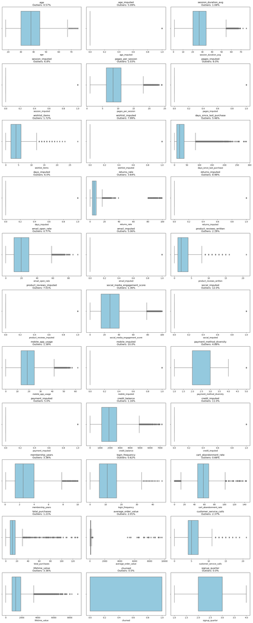

|  | column | low_bound | high_bound | outlier_count | outlier_% |
| --- | --- | --- | --- | --- | --- |
| 17 | social_imputed | 0.00 | 0.00 | 5994 | 12.00 |
| 23 | credit_imputed | 0.00 | 0.00 | 5495 | 11.00 |
| 19 | mobile_imputed | 0.00 | 0.00 | 4997 | 10.00 |
| 11 | returns_imputed | 0.00 | 0.00 | 4486 | 8.98 |
| 7 | wishlist_imputed | 0.00 | 0.00 | 3993 | 7.99 |
| 15 | product_reviews_imputed | 0.00 | 0.00 | 3500 | 7.01 |
| 3 | session_imputed | 0.00 | 0.00 | 3397 | 6.80 |
| 9 | days_imputed | 0.00 | 0.00 | 2998 | 6.00 |
| 5 | pages_imputed | 0.00 | 0.00 | 2997 | 6.00 |
| 8 | days_since_last_purchase | -36.00 | 84.00 | 2726 | 5.46 |
| 1 | age_imputed | 0.00 | 0.00 | 2542 | 5.09 |
| 13 | email_imputed | 0.00 | 0.00 | 2527 | 5.06 |
| 21 | payment_imputed | 0.00 | 0.00 | 2498 | 5.00 |
| 20 | payment_method_diversity | 0.50 | 4.50 | 2436 | 4.88 |
| 10 | returns_rate | -5.15 | 16.85 | 1821 | 3.64 |
| 24 | membership_years | -2.50 | 7.90 | 1677 | 3.36 |
| 30 | lifetime_value | -836.83 | 3500.59 | 1680 | 3.36 |
| 29 | customer_service_calls | -0.50 | 11.50 | 1185 | 2.37 |
| 14 | product_reviews_written | -3.50 | 8.50 | 1088 | 2.18 |
| 28 | average_order_value | 0.97 | 230.53 | 1002 | 2.01 |
| 6 | wishlist_items | -4.00 | 12.00 | 857 | 1.72 |
| 18 | mobile_app_usage | -3.90 | 41.70 | 691 | 1.38 |
| 16 | social_media_engagement_score | -22.80 | 78.80 | 679 | 1.36 |
| 27 | total_purchases | -5.50 | 30.50 | 604 | 1.21 |
| 22 | credit_balance | -1086.00 | 4914.00 | 578 | 1.16 |
| 2 | session_duration_avg | -0.50 | 54.70 | 541 | 1.08 |
| 4 | pages_per_session | -1.00 | 18.20 | 513 | 1.03 |
| 12 | email_open_rate | -18.30 | 58.50 | 384 | 0.77 |
| 26 | cart_abandonment_rate | 13.14 | 102.04 | 329 | 0.66 |
| 25 | login_frequency | -10.50 | 33.50 | 309 | 0.62 |
| 0 | age | 7.50 | 67.50 | 285 | 0.57 |
| 31 | churned | -1.50 | 2.50 | 0 | 0.00 |
| 32 | signup_quarter | 0.50 | 4.50 | 0 | 0.00 |

```python
detect_outliers(df, show_plots=True)
```

## Demographic Overview

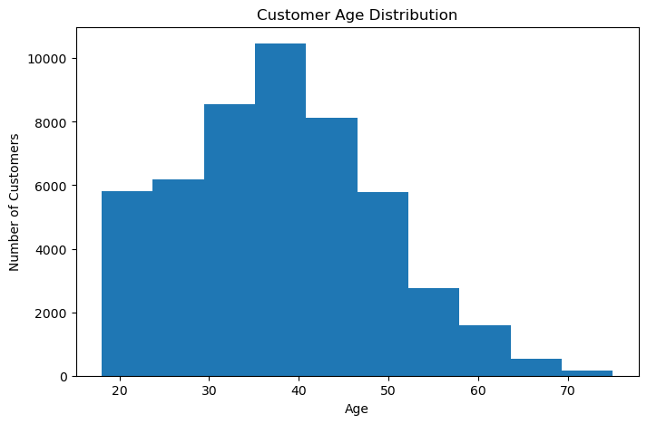

```python
plt.figure(figsize=(8,5))

plt.hist(df['age'], bins=10)

plt.title('Customer Age Distribution')
plt.xlabel('Age')
plt.ylabel('Number of Customers')

plt.show()
```

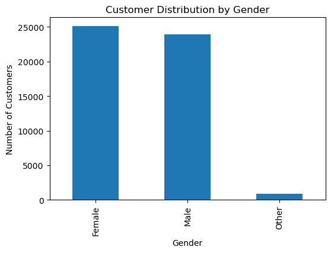

```python
gender_counts = df['gender'].value_counts()

plt.figure(figsize=(6,4))

gender_counts.plot(kind='bar')

plt.title('Customer Distribution by Gender')
plt.xlabel('Gender')
plt.ylabel('Number of Customers')

plt.show()
```

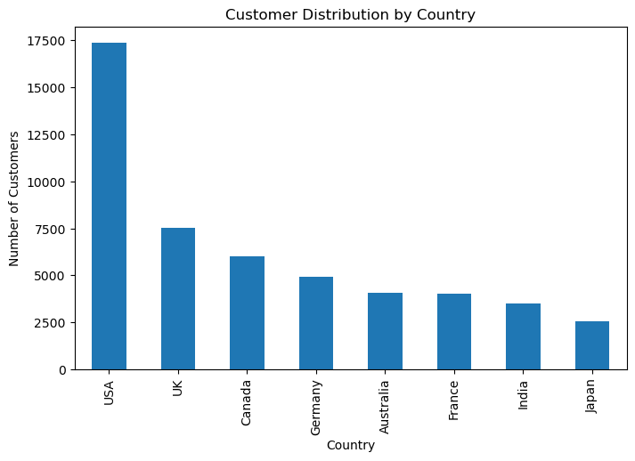

```python
country_counts = df['country'].value_counts()

plt.figure(figsize=(8,5))

country_counts.plot(kind='bar')

plt.title('Customer Distribution by Country')
plt.xlabel('Country')
plt.ylabel('Number of Customers')

plt.show()
```

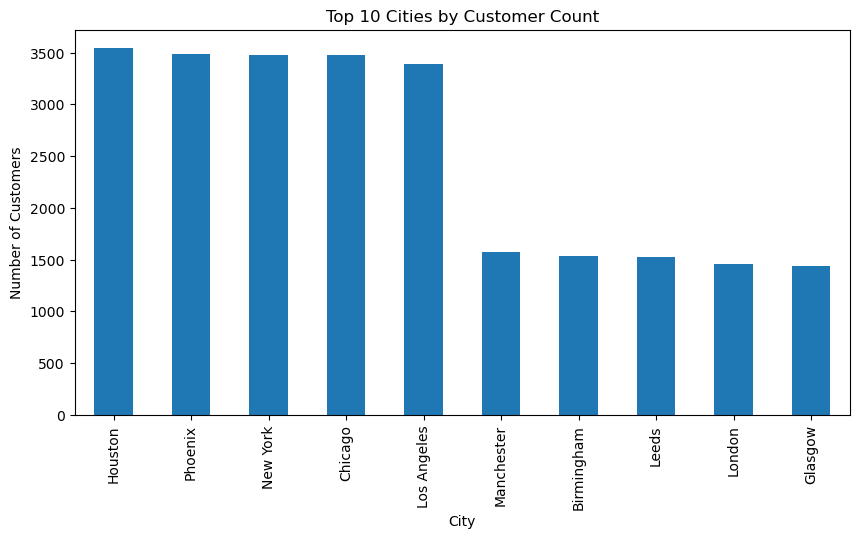

```python
city_counts = df['city'].value_counts().head(10)

plt.figure(figsize=(10,5))

city_counts.plot(kind='bar')

plt.title('Top 10 Cities by Customer Count')
plt.xlabel('City')
plt.ylabel('Number of Customers')

plt.show()
```

### Demographic Analysis Summary

- Most customers were between 25 and 50 years old, with the highest concentration in the mid-to-late 30s.
- Gender distribution was relatively balanced.
- The United States represented the largest customer market.
- Major cities such as Houston, Phoenix, New York, Chicago, and Los Angeles contained the largest customer populations.

## Correlation - Lifetime Value

```python
corr_ltv = (
    df.corr(numeric_only=True)['lifetime_value']
      .sort_values(ascending=False)
      .round(2)
)

print(corr_ltv)

corr_ltv = corr.drop('lifetime_value')

top_corr = pd.concat([
    corr_ltv.head(10),
    corr_ltv.tail(2)
])

plt.figure(figsize=(10,6))
top_corr.sort_values().plot(kind='barh')

plt.title('Top Factors Associated with Customer Lifetime Value')
plt.xlabel('Correlation Coefficient')
plt.tight_layout()
plt.show()
```

```
lifetime_value                   1.00
total_purchases                  0.63
session_duration_avg             0.54
pages_per_session                0.52
mobile_app_usage                 0.50
login_frequency                  0.50
email_open_rate                  0.46
wishlist_items                   0.46
social_media_engagement_score    0.43
product_reviews_written          0.40
credit_balance                   0.38
average_order_value              0.15
days_since_last_purchase         0.01
payment_imputed                  0.01
payment_method_diversity         0.01
pages_imputed                    0.01
membership_years                 0.00
social_imputed                   0.00
product_reviews_imputed          0.00
returns_rate                     0.00
age                              0.00
credit_imputed                   0.00
age_imputed                     -0.00
signup_quarter                  -0.00
returns_imputed                 -0.00
wishlist_imputed                -0.00
mobile_imputed                  -0.01
days_imputed                    -0.01
churned                         -0.01
email_imputed                   -0.10
session_imputed                 -0.12
customer_service_calls          -0.29
cart_abandonment_rate           -0.50
Name: lifetime_value, dtype: float64
```

[output not shown]

```python
corr_churn = (
    df.corr(numeric_only=True)['churned']
      .sort_values(ascending=False)
      .round(2)
)

print(corr_churn)
```

[output not shown]

[output not shown]

[figure not shown]

```python
corr_churn = (
    df.corr(numeric_only=True)['churned']
      .drop('churned')
      .sort_values(ascending=False)
)

print(corr_churn)

high_corr = pd.concat([
    corr_churn.head(10),
    corr_churn.tail(2)
])

plt.figure(figsize=(10,6))
high_corr.sort_values().plot(kind='barh')

plt.title('Top Factors Associated with Customer Churn')
plt.xlabel('Correlation Coefficient')
plt.tight_layout()
plt.show()
```

### Correlation Analysis

Lifetime Value

- Total purchases showed the strongest positive relationship with lifetime value.
- Login frequency, mobile app usage, and social media engagement were positively related to customer value.
- Cart abandonment rate showed a strong negative relationship with lifetime value.

Churn

- Cart abandonment rate and customer service calls showed positive relationships with churn.
- Email engagement, mobile app usage, and purchasing activity were negatively related to churn.
- Engagement metrics generally indicated lower churn risk.

### Login Frequency vs Lifetime Value

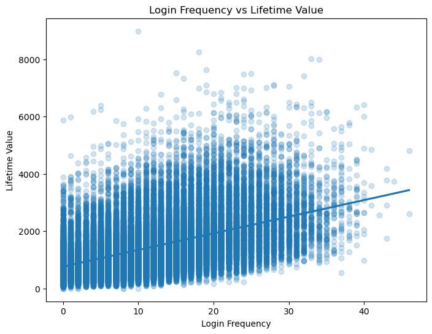

```python
plt.figure(figsize=(8,6))

sns.regplot(
    data=df,
    x='login_frequency',
    y='lifetime_value',
    scatter_kws={'alpha':0.2}
)

plt.title('Login Frequency vs Lifetime Value')
plt.xlabel('Login Frequency')
plt.ylabel('Lifetime Value')

plt.show()
```

### Social Media Engagement vs Lifetime Value

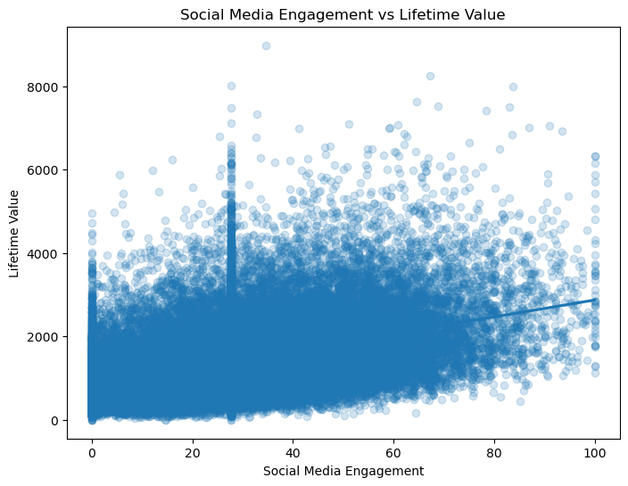

```python
plt.figure(figsize=(8,6))

sns.regplot(
    data=df,
    x='social_media_engagement_score',
    y='lifetime_value',
    scatter_kws={'alpha':0.2}
)

plt.title('Social Media Engagement vs Lifetime Value')
plt.xlabel('Social Media Engagement')
plt.ylabel('Lifetime Value')

plt.show()
```

### Mobile App Usage vs Lifetime Value

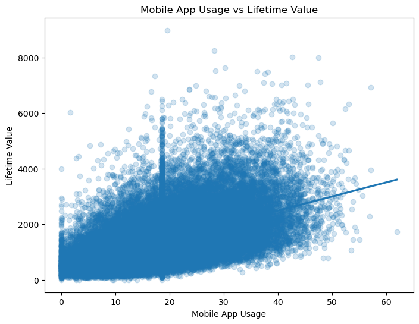

```python
plt.figure(figsize=(8,6))

sns.regplot(
    data=df,
    x='mobile_app_usage',
    y='lifetime_value',
    scatter_kws={'alpha':0.2}
)

plt.title('Mobile App Usage vs Lifetime Value')
plt.xlabel('Mobile App Usage')
plt.ylabel('Lifetime Value')

plt.show()
```

### Cart Abandonment vs Lifetime Value

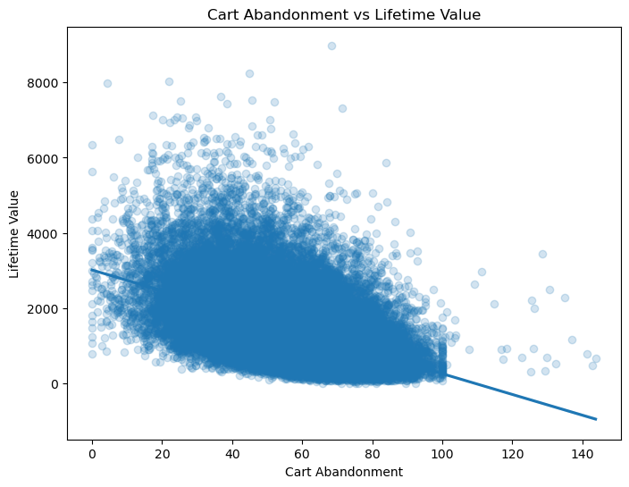

```python
plt.figure(figsize=(8,6))

sns.regplot(
    data=df,
    x='cart_abandonment_rate',
    y='lifetime_value',
    scatter_kws={'alpha':0.2}
)

plt.title('Cart Abandonment vs Lifetime Value')
plt.xlabel('Cart Abandonment')
plt.ylabel('Lifetime Value')

plt.show()
```

### Customer Lifetime Value

- Customers with higher login frequency tended to generate greater lifetime value.
- Social media engagement showed a positive relationship with customer value.
- Mobile app usage was associated with higher lifetime value.
- Higher cart abandonment rates were associated with lower customer value.

### Customer Service Calls vs Churned

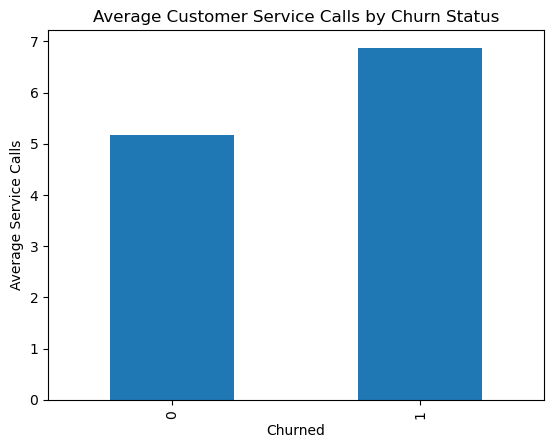

```python
churn_calls = df.groupby('churned')['customer_service_calls'].mean()

churn_calls.plot(kind='bar')
plt.title('Average Customer Service Calls by Churn Status')
plt.xlabel('Churned')
plt.ylabel('Average Service Calls')
plt.show()
```

### Email Engagement vs Churned

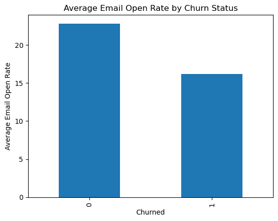

```python
churn_calls = df.groupby('churned')['email_open_rate'].mean()

churn_calls.plot(kind='bar')
plt.title('Average Email Open Rate by Churn Status')
plt.xlabel('Churned')
plt.ylabel('Average Email Open Rate')
plt.show()
```

### Customer Churn

- Churned customers made more customer service calls on average.
- Active customers exhibited higher email engagement than churned customers.
- Engagement-related metrics generally aligned with lower churn rates.

## Churn Prediction Model

```python
## predictor variabled selected based on analysis
features = [
    'session_duration_avg',
    'pages_per_session',
    'wishlist_items',
    'days_since_last_purchase',
    'returns_rate',
    'email_open_rate',
    'product_reviews_written',
    'social_media_engagement_score',
    'mobile_app_usage',
    'payment_method_diversity',
    'credit_balance',
    'membership_years',
    'login_frequency',
    'cart_abandonment_rate',
    'total_purchases',
    'average_order_value',
    'customer_service_calls'
]

## defining x and y
x = df[features]
y = df['churned']

## Train and Test split
x_train, x_test, y_train, y_test = train_test_split(
    x,
    y,
    test_size=0.2,
    random_state=42,
    stratify=y
)

## Training the model
model = LogisticRegression(max_iter=5000)

model.fit(x_train, y_train)

## Predictions
y_pred = model.predict(x_test)

## Probabilities
y_prob = model.predict_proba(x_test)[:,1]

## Evaluation
print("Accuracy:", accuracy_score(y_test, y_pred))
print("\nClassification Report")
print(classification_report(y_test, y_pred))

print("\nConfusion Matrix")
print(confusion_matrix(y_test, y_pred))

## Add probabilities back to dataframe
df['churn_probability'] = model.predict_proba(x)[:,1]

## Risk Levels
df['risk_level'] = pd.cut(
    df['churn_probability'],
    bins=[0, 0.3, 0.7, 1],
    labels=['Low Risk', 'Medium Risk', 'High Risk']
)

print("\nRisk Level Distribution")
print(df['risk_level'].value_counts())
```

```
Accuracy: 0.7679143314651722

Classification Report
              precision    recall  f1-score   support

           0       0.78      0.94      0.85      7103
           1       0.71      0.34      0.46      2889

    accuracy                           0.77      9992
   macro avg       0.74      0.64      0.65      9992
weighted avg       0.76      0.77      0.74      9992


Confusion Matrix
[[6699  404]
 [1915  974]]

Risk Level Distribution
risk_level
Low Risk       29294
Medium Risk    19368
High Risk       1298
Name: count, dtype: int64
```

```python
coef_df = pd.DataFrame({
    'feature': x.columns,
    'Coefficient': model.coef_[0]
})

coef_df.sort_values(
    by='Coefficient',
    ascending=False
)
```

|  | feature | Coefficient |
| --- | --- | --- |
| 16 | customer_service_calls | 0.189698 |
| 13 | cart_abandonment_rate | 0.030412 |
| 14 | total_purchases | 0.015735 |
| 4 | returns_rate | 0.012904 |
| 3 | days_since_last_purchase | 0.012614 |
| 11 | membership_years | 0.009734 |
| 0 | session_duration_avg | 0.005340 |
| 15 | average_order_value | 0.000775 |
| 7 | social_media_engagement_score | 0.000245 |
| 10 | credit_balance | 0.000018 |
| 12 | login_frequency | -0.000441 |
| 9 | payment_method_diversity | -0.000579 |
| 8 | mobile_app_usage | -0.000624 |
| 2 | wishlist_items | -0.003986 |
| 5 | email_open_rate | -0.011433 |
| 6 | product_reviews_written | -0.014850 |
| 1 | pages_per_session | -0.030740 |